# Sequence alignment

Marc A.T. Teunis

2019-05-12

# Contents

## 0.1 Introduction

Learn:

- How to perform multiple alignment
- How to build graphs for alignment
- How to build a fylogenetic tree
- How and why to build `DNAStringset` and `AAStringSet` objects
- Appply sequence alignment in `{DECIPHER}` package on a new dataset

## 0.2 Packages

```r
library(msa)
library(tidyverse)
library(biomaRt)
library(annotate)
library(Biostrings)
library(seqinr)
# install.packages('msaR')
library(DECIPHER)
```

## 0.3 Vignettes

```r
browseVignettes("msaR")
browseVignettes("DECIPHER")
system.file("tex", "texshade.sty", package="msa")
```

## 0.4 Theory

Sequence alignment is important tool to investigate structural, evolutionary and mechanistical simularities in (biological) strings.

One algorithm used to score alignment of strings is the `Needleman-Wunsch` algorithm.

The exect details of the algorithm are out of scope for this lesson. Wikipedia ia good source for details: https://en.wikipedia.org/wiki/Needleman%E2%80%93Wunsch_algorithm

## 0.5 Data

Remember the data with the homolog sequences for Caspase-3, -4 and -5 from Human, Orang Utan and Mouse? We will use it here to learn how to use Bioconductor to do multiple sequence alignments.

```r
example_caspase <- read_rds(path = file.path(root, "data", "biomaRt_homology_example_aa.rds"))
example_caspase_dna <- read_rds(path = file.path(root, "data", "biomaRt_homology_example_dna.rds"))
```

## 0.6 Filter for Caspase-4

For example sake we use the sequences for Caspase-4 only. To select the right caspases, we need to convert to lower case for all the symbol names

```r
example_caspase$external_gene_name <- tolower(example_caspase$external_gene_name)
levels(as.factor(example_caspase$external_gene_name))
```

```
## [1] "casp3" "casp4" "casp5"
```

```r
casp4 <- example_caspase %>%
  filter(external_gene_name == "casp4")
casp4
```

```
## # A tibble: 7 x 4
##   amino_acid_sequence              ensembl_gene_id  external_gene_n~ species
##   <chr>                            <chr>            <chr>            <chr>
## 1 MADAMKKKHSKVGEMLLQTFFSVDPGSHHGE~ ENSMUSG00000033~ casp4            M. musc~
## 2 MAENKHPDKPLKVLEQLGKEVLTEYLEKLVQ~ ENSMUSG00000033~ casp4            M. musc~
## 3 MAENKHPDKPLKVLEQLGKEVLTEYLEKLVQ~ ENSMUSG00000033~ casp4            M. musc~
## 4 MADSMQEKQRMAGQMLLQTFFNIDQISPNKK~ ENSG00000196954  casp4            H. sapi~
## 5 MAEGNHRKKPLKVLESLGKDFLTGVLDNLVE~ ENSG00000196954  casp4            H. sapi~
## 6 MAEGNHRKKPLKVLESLGKDFLTGVLDNLVE~ ENSG00000196954  casp4            H. sapi~
## 7 MAEGNHRKKPLKMLESLGKDFLTGVLDNLVE~ ENSPPYG00000003~ casp4            P. abel~
```

## 0.7 AAStringSet

```r
caspase_aa <- AAStringSet(casp4$amino_acid_sequence)
caspase_aa
```

```
##   A AAStringSet instance of length 7
##     width seq
## [1]    93 MADAMKKKHSKVGEMLLQTFFSVDPGSHHGEA...TQEIYPIKEANGRTRKALIICNTEFKHLSLRY
## [2]   374 MAENKHPDKPLKVLEQLGKEVLTEYLEKLVQS...QQSFEKASIHSQMPTIDRATLTRYFYLFPGN*
## [3]   119 MAENKHPDKPLKVLEQLGKEVLTEYLEKLVQS...DLPNKGGQWPYTKGSYHMQYRVQTSLTEVWG*
## [4]   322 MADSMQEKQRMAGQMLLQTFFNIDQISPNKKA...QQSFETPRAKAQMPTIERLSMTRYFYLFPGN*
## [5]   378 MAEGNHRKKPLKVLESLGKDFLTGVLDNLVEQ...QQSFETPRAKAQMPTIERLSMTRYFYLFPGN*
## [6]   147 MAEGNHRKKPLKVLESLGKDFLTGVLDNLVEQ...RLCKERAEEIYPIKERNNRTRLALIICNTEFD
## [7]   378 MAEGNHRKKPLKMLESLGKDFLTGVLDNLVEQ...QQSFETPRAKAQMPTIERLSMTRYFYLFPGN*
```

## 0.8 Set names to AAStringSet sequences

```r
names(caspase_aa) <- paste(casp4$species, casp4$ensembl_gene_id, sep = "_")
#duplicated(casp5$coding[1:42])
caspase_aa
```

```
##   A AAStringSet instance of length 7
##     width seq                                            names
## [1]    93 MADAMKKKHSKVGEMLLQTFFS...GRTRKALIICNTEFKHLSLRY M. musculus_ENSMU...
## [2]   374 MAENKHPDKPLKVLEQLGKEVL...QMPTIDRATLTRYFYLFPGN* M. musculus_ENSMU...
## [3]   119 MAENKHPDKPLKVLEQLGKEVL...TKGSYHMQYRVQTSLTEVWG* M. musculus_ENSMU...
## [4]   322 MADSMQEKQRMAGQMLLQTFFN...QMPTIERLSMTRYFYLFPGN* H. sapiens_ENSG00...
## [5]   378 MAEGNHRKKPLKVLESLGKDFL...QMPTIERLSMTRYFYLFPGN* H. sapiens_ENSG00...
## [6]   147 MAEGNHRKKPLKVLESLGKDFL...PIKERNNRTRLALIICNTEFD H. sapiens_ENSG00...
## [7]   378 MAEGNHRKKPLKMLESLGKDFL...QMPTIERLSMTRYFYLFPGN* P. abelii_ENSPPYG...
```

# 1 Aligment of sequences, using the {msa} package

## 1.1 Using the `{msa}` package

```r
caspase_align <- msa::msa(caspase_aa)
```

```
## use default substitution matrix
```

```r
caspase_align
```

```
## CLUSTAL 2.1
##
## Call:
##    msa::msa(caspase_aa)
##
## MsaAAMultipleAlignment with 7 rows and 557 columns
##     aln                                                 names
## [1] MAEGNHRKKPLKVLESLGKDFLTG...------------------------ H. sapiens_ENSG00...
## [2] MAEGNHRKKPLKMLESLGKDFLTG...AKAQMPTIERLSMTRYFYLFPGN- P. abelii_ENSPPYG...
## [3] ------------------------...AKAQMPTIERLSMTRYFYLFPGN- H. sapiens_ENSG00...
## [4] MAEGNHRKKPLKVLESLGKDFLTG...AKAQMPTIERLSMTRYFYLFPGN- H. sapiens_ENSG00...
## [5] MAENKHPDKPLKVLEQLGKEVLTE...------------------------ M. musculus_ENSMU...
## [6] MAENKHPDKPLKVLEQLGKEVLTE...------------------------ M. musculus_ENSMU...
## [7] MADAMK-KKHSKVGEMLLQTFFSV...------------------------ M. musculus_ENSMU...
## Con MAE??H?KKPLKVLE?LGK?FLT?...------------------------ Consensus
```

## 1.2 Print alignment

```r
print(caspase_align, show="complete")
```

```
##
## MsaAAMultipleAlignment with 7 rows and 557 columns
##     aln (1..51)                                         names
## [1] MAEGNHRKKPLKVLESLGKDFLTGVLDNLVEQNVLNWKEEEKKKYYDAKTE H. sapiens_ENSG00...
## [2] MAEGNHRKKPLKMLESLGKDFLTGVLDNLVEQNVLNWKEEEKKKYYDAKTE P. abelii_ENSPPYG...
## [3] --------------------------------------------------- H. sapiens_ENSG00...
## [4] MAEGNHRKKPLKVLESLGKDFLTGVLDNLVEQNVLNWKEEEKKKYYDAKTE H. sapiens_ENSG00...
## [5] MAENKHPDKPLKVLEQLGKEVLTEYLEKLVQSNVLKLKEEDKQKFNNAERS M. musculus_ENSMU...
## [6] MAENKHPDKPLKVLEQLGKEVLTEYLEKLVQSNVLKLKEEDKQKFNNAERS M. musculus_ENSMU...
## [7] MADAMK-KKHSKVGEMLLQTFFSVDPGSHHGEANLEMEEPE-ESLNTLKLC M. musculus_ENSMU...
## Con MAE??H?KKPLKVLE?LGK?FLT??L??LV??NVL??KEEEK?K???AK?? Consensus
##
##     aln (52..102)                                       names
## [1] DKVRVMADSMQEKQRMAGQMLLQTFFNIDQISPNKK--------------- H. sapiens_ENSG00...
## [2] DKVRVMADSIQEKQRMAGQMLLQTFFNIDQISPNKK--------------- P. abelii_ENSPPYG...
## [3] -----MADSMQEKQRMAGQMLLQTFFNIDQISPNKK--------------- H. sapiens_ENSG00...
## [4] DKVRVMADSMQEKQRMAGQMLLQTFFNIDQISPNKK--------------- H. sapiens_ENSG00...
## [5] DKRWVFVDAMKKKHSKVGEMLLQTFFSVDPGSHHGEANLEMEEPEESLNTL M. musculus_ENSMU...
## [6] DKRWVFVDAMKKKHSKVGEMLLQTFFSVDPGSHHG---------------- M. musculus_ENSMU...
## [7] SP---------EEFTRLCREKTQEIYPIKEANGRT---------------- M. musculus_ENSMU...
## Con DK??VMADSMQEKQRMAGQMLLQTFFNIDQISPNKK--------------- Consensus
##
##     aln (103..153)                                      names
## [1] --------------------------------------------------- H. sapiens_ENSG00...
## [2] --------------------------------------------------- P. abelii_ENSPPYG...
## [3] --------------------------------------------------- H. sapiens_ENSG00...
## [4] --------------------------------------------------- H. sapiens_ENSG00...
## [5] KLCSPEEFTRLCREKTQEIYPIKEANGRTRKALIICNTEFKHLSLRYGANF M. musculus_ENSMU...
## [6] --------------------------------------------------- M. musculus_ENSMU...
## [7] --------------------------------------------------- M. musculus_ENSMU...
## Con --------------------------------------------------- Consensus
##
##     aln (154..204)                                      names
## [1] -------AHPNMEAG------------------------------------ H. sapiens_ENSG00...
## [2] -------AHPNMEAG------------------------------------ P. abelii_ENSPPYG...
## [3] -------AHPNMEAG------------------------------------ H. sapiens_ENSG00...
## [4] -------AHPNMEAG------------------------------------ H. sapiens_ENSG00...
## [5] DIIGMKGLLEDLGYDVVVKEELTAEGMESEMKDFAALSEHQTSDSTFLVLM M. musculus_ENSMU...
## [6] ---------EDL--------------------------------------- M. musculus_ENSMU...
## [7] --------------------------------------------------- M. musculus_ENSMU...
```

[output cut: 56 more lines]

```
## [4] QSSENLEEDAVYKTHVEKDFIAFCSSTPHNVSWRDSTMGSIFITQLITCFQ H. sapiens_ENSG00...
## [5] --------------------------------------------------- M. musculus_ENSMU...
## [6] --------------------------------------------------- M. musculus_ENSMU...
## [7] --------------------------------------------------- M. musculus_ENSMU...
## Con --------------------------------------------------- Consensus
##
##     aln (511..557)                                  names
## [1] ----------------------------------------------- H. sapiens_ENSG00...
## [2] KYSWCCHLEEVFRKVQQSFETPRAKAQMPTIERLSMTRYFYLFPGN- P. abelii_ENSPPYG...
## [3] KYSWCCHLEEVFRKVQQSFETPRAKAQMPTIERLSMTRYFYLFPGN- H. sapiens_ENSG00...
## [4] KYSWCCHLEEVFRKVQQSFETPRAKAQMPTIERLSMTRYFYLFPGN- H. sapiens_ENSG00...
## [5] ----------------------------------------------- M. musculus_ENSMU...
## [6] ----------------------------------------------- M. musculus_ENSMU...
## [7] ----------------------------------------------- M. musculus_ENSMU...
## Con ----------------------------------------------- Consensus
```

## 1.3 Pretty print aligment

```r
## does not work on my pc
msaPrettyPrint(caspase_align, output="",  y=c(10, 30), showNames="none",
               showLogo="none", askForOverwrite=FALSE, verbose=FALSE)
```

# 2 Alignment using the {DECIPHER} package

## 2.1 Amino acids

```r
AA <- AlignSeqs(caspase_aa, processors = 8) # align the translation
BrowseSeqs(AA, highlight=1) # view the alignment
```

## 2.2 Alignment in browser

[figure not shown]

## 2.3 Subsetting an alignment

Subsetting an alignment works the same as for ranges. First we select the sequences that we want subset, using normal indexing with `[]`, than we use the function `Biostrings::subseq()`

Let’s look at the sequence 5 for Human and 7 for Orang Utan only

```r
caspase_aa
AA_subs <- Biostrings::subseq(caspase_aa[c(5, 7),], start = 1, end = 158)

AA_subs <- AlignSeqs(AA_subs, processors = 8) # align the translation
BrowseSeqs(AA_subs, highlight=1) # view the alignment
```

## 2.4 Alignment in browser

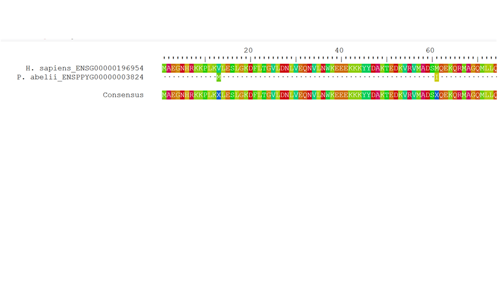

## 2.5 Aligning Amino acid sequences from DNA sequences

To align a translation from DNA use the `AlignTranslation()` function from `{DECIPHER}`

```r
dna_strings <- DNAStringSet(example_caspase_dna$coding)
names(dna_strings) <- paste(example_caspase_dna$external_gene_name,
                            example_caspase$species)

AA <- AlignTranslation(dna_strings, type="AAStringSet") # align the translation
BrowseSeqs(AA, highlight=1) # view the alignment
```

## 2.6 Alignment in browser

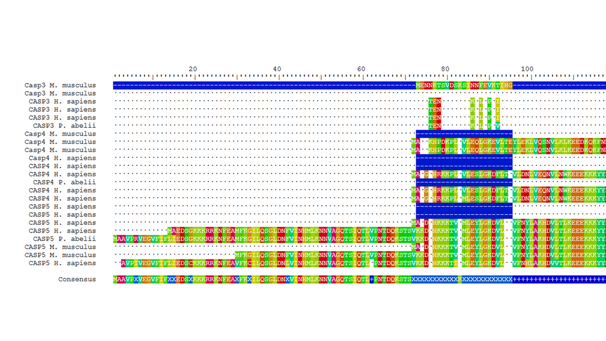

## 2.7 Caspase-4 DNA

Let’s look at the DNA alignments for the caspase-4 human and oran-utan subset above

```r
casp4_dna <- example_caspase_dna %>%
  dplyr::mutate(external_gene_name = tolower(external_gene_name)) %>%
  dplyr::filter(species == "H. sapiens" | species == "P. abelii") %>%
  dplyr::filter(external_gene_name == "casp4") %>%
  print()
```

```
## # A tibble: 5 x 4
##   coding                           ensembl_gene_id  external_gene_n~ species
##   <chr>                            <chr>            <chr>            <chr>
## 1 ATGGCAGACTCTATGCAAGAGAAGCAACGTA~ ENSG00000196954  casp4            H. sapi~
## 2 ATGGCAGAAGGCAACCACAGAAAAAAGCCAC~ ENSG00000196954  casp4            H. sapi~
## 3 NACAACGTGTCCTGGAGAGACAGCACAATGG~ ENSG00000196954  casp4            H. sapi~
## 4 ATGGCAGAAGGCAACCACAGAAAAAAGCCAC~ ENSG00000196954  casp4            H. sapi~
## 5 ATGGCAGAAGGCAACCACAGAAAAAAACCAC~ ENSPPYG00000003~ casp4            P. abel~
```

```r
dna_subset <- DNAStringSet(casp4_dna$coding)
names(dna_subset) <- paste(casp4_dna$species, casp4_dna$ensembl_gene_id, sep = "_")
```

## 2.8 Aligning Human and Orang Utan sequences

```r
casp_dna_subset <- AlignSeqs(dna_subset[c(4,5),], processors = 8)
BrowseSeqs(casp_dna_subset, highlight=1) # view the alignment
```

How do the DNA and Amino acid aligment relate?

## 2.9 Alignment in browser

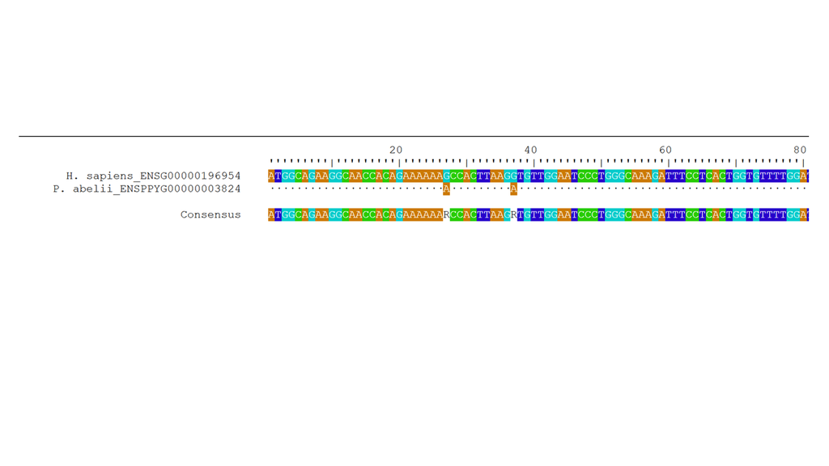

## 2.10 Inspecting alignment Quality

- Look at the alignment
- `BrowseSeqs()`

```r
BrowseSeqs(caspase_aa[c(5, 7),], highlight = 0)
```

## 2.11 Fylogenetic alignment (Evolutionary relationships)

We create a fylogeny for Caspase-4, using the DNA from Human, Orang Utan and Mouse. Below we filter the DNA dataset for the relevant data

```r
mouse_human_orang_dna <- example_caspase_dna %>%
  dplyr::mutate(external_gene_name = tolower(external_gene_name)) %>%
  dplyr::filter(external_gene_name == "casp4") %>%
  print
```

```
## # A tibble: 9 x 4
##   coding                          ensembl_gene_id   external_gene_n~ species
##   <chr>                           <chr>             <chr>            <chr>
## 1 ATGGCTGATGCCATGAAAAAGAAACACAGC~ ENSMUSG000000335~ casp4            M. musc~
## 2 ATGGCTGAAAACAAACACCCTGACAAACCA~ ENSMUSG000000335~ casp4            M. musc~
## 3 ATGGCTGAAAACAAACACCCTGACAAACCA~ ENSMUSG000000335~ casp4            M. musc~
## 4 NGCAGTGACAAGCGTTGGGTTTTTGTAGAT~ ENSMUSG000000335~ casp4            M. musc~
## 5 ATGGCAGACTCTATGCAAGAGAAGCAACGT~ ENSG00000196954   casp4            H. sapi~
## 6 ATGGCAGAAGGCAACCACAGAAAAAAGCCA~ ENSG00000196954   casp4            H. sapi~
## 7 NACAACGTGTCCTGGAGAGACAGCACAATG~ ENSG00000196954   casp4            H. sapi~
## 8 ATGGCAGAAGGCAACCACAGAAAAAAGCCA~ ENSG00000196954   casp4            H. sapi~
## 9 ATGGCAGAAGGCAACCACAGAAAAAAACCA~ ENSPPYG000000038~ casp4            P. abel~
```

## 2.12 Prepare alignment for fylogeny

```r
mouse_human_orang_dna_string_set <- DNAStringSet(mouse_human_orang_dna$coding,
                                                 start = 1, end = 210)
names(mouse_human_orang_dna_string_set) <- mouse_human_orang_dna$species

alignment_aa <- AlignTranslation(mouse_human_orang_dna_string_set,
                                 type = "AAStringSet", processors = 8)
staggered <- StaggerAlignment(alignment_aa)
BrowseSeqs(staggered)
```

## 2.13 Alignment in browser

[figure not shown]

## 2.14 Fylogenetic tree from distance matrix

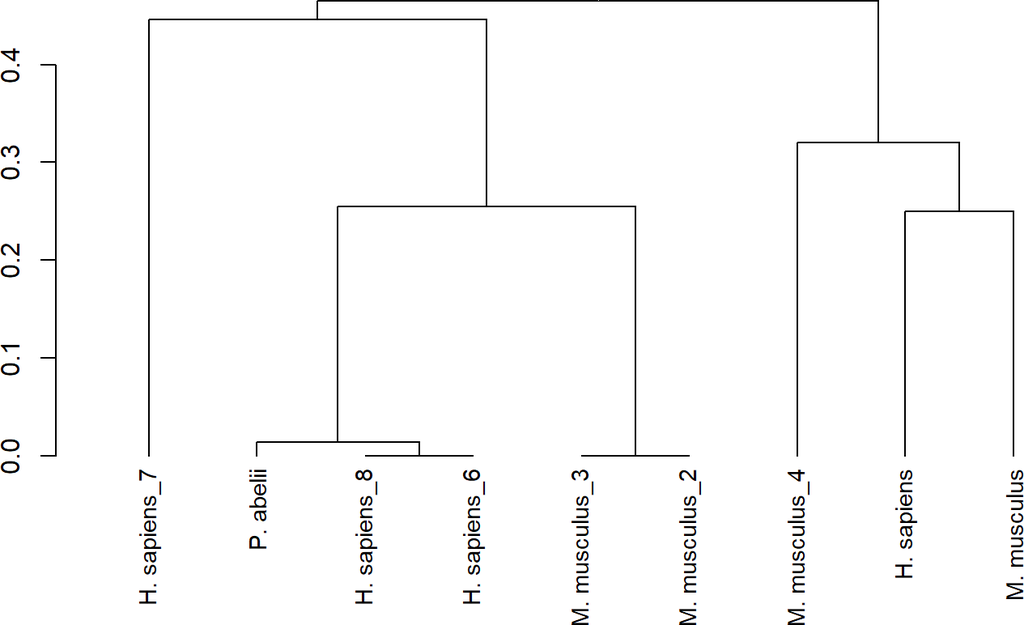

```r
distance_matrix <- DistanceMatrix(staggered)
dendrogram <- IdClusters(distance_matrix, showPlot = TRUE, type = 'both')
```

## 2.15 Accessing the dendrogram plot

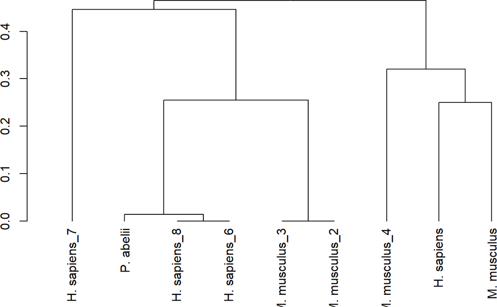

```r
plot(dendrogram[[2]])
```

## 2.16 Save the plot

```r
png(filename = "./images/dendrogram.png")
plot(plot[[2]])
dev.off()
```

## 2.17 Aligning RNA sequences

16S ribosomal rRNA is used to characterize bacteria. Here we show an example with the build-in dataset from {DECIPHER}

```r
# database containing 16S ribosomal RNA sequences
db <- system.file("extdata", "Bacteria_175seqs.sqlite", package="DECIPHER")
rna <- SearchDB(db, remove="all", type="RNAStringSet")
```

```
## Search Expression:
## select row_names, sequence from _Seqs where row_names in (select row_names
## from Seqs)
##
## RNAStringSet of length: 175
## Time difference of 0.03 secs
```

```r
alignedRNA <- AlignSeqs(rna, processors = 8, verbose = FALSE) # align with RNA secondary structure
```

## 2.18 Viewing the alignment

```r
BrowseSeqs(alignedRNA)
```

## 2.19 Alignment in browser

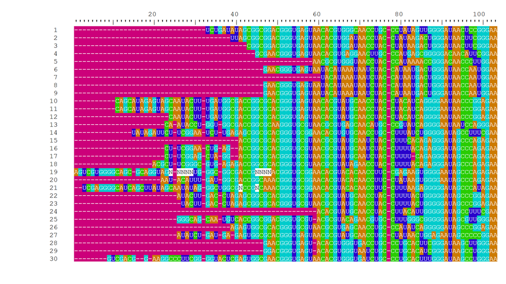

## 2.20 Bacterial fylogenetic tree

```r
distance_matrix <- DistanceMatrix(StaggerAlignment(alignedRNA), verbose = FALSE)
bacteria <- IdClusters(distance_matrix, showPlot = TRUE, type = 'dendrogram')
```

## 2.21 Bacterial dendrogram (fylogenetic tree)

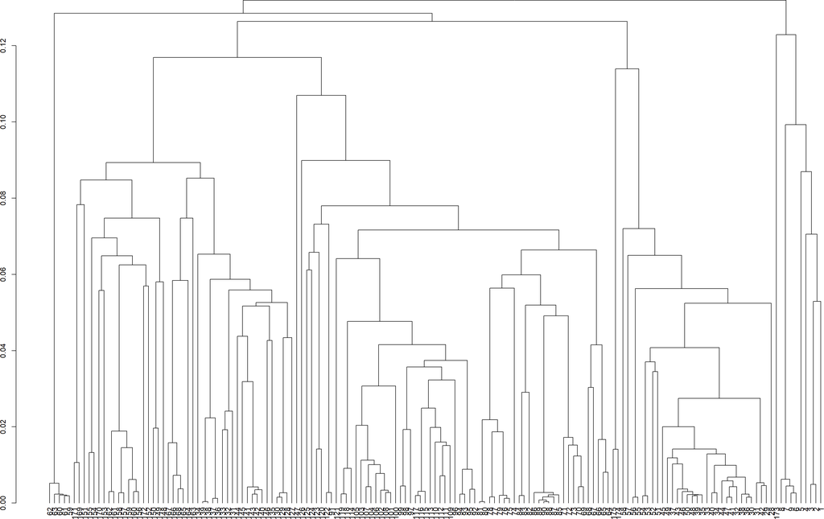

```r
bacteria[[2]] %>% plot()
```